# Regression Models

Sébastien Plat

# Linear Least Square Regression

## Definition

Regression Models are used to understand relathionships / predict outcomes based on existing data.

Let’s try to describe the relation between two variables $X_i$ and $Y_i$ as linear, with **Gaussian errors** added to the linear fit (**probabilistic model** for Linear Regression):

$Y_i = \beta_0 + \beta_1 X_i + \epsilon_{i} = \hat Y_i + \epsilon_{i} ~~ where~\epsilon_{i}~are~iid~N(0, \sigma^2)$

## Line of best fit

We want to find the **line of best fit**, ie. the line that is the best approximation of the given set of data. It is the line that **minimizes the square errors**, ie. the **difference between the predictions and actual outcomes**:

$Min (\sum_{i=1}^n (Y_i - \hat Y_i)^2=Min~{\epsilon_i}^2~~\bullet~~ \beta_1 = Cor(X, Y) \times \frac{Sd(Y)}{Sd(X)}~~\bullet~~\beta_0 = \bar Y - \hat \beta_1 \bar X$

- The line passes through the point $(\bar X, \bar Y$)
- If we choose $\beta_1 = 0$ (reg through the origin), then $\beta_0 = \bar Y$
- For centered data $(X_i - \bar X, Y_i - \bar Y)$:
  - the slope is unchanged
  - the regression goes through the origin (as both means equal zero)

*Note: For normalized data $\{ \frac{X_i - \bar X}{Sd(X)}, \frac{Y_i - \bar Y}{Sd(Y)}\}$, the slope is $Cor(Y, X)$.*

### Intercept

The **intercept** (ITC) $\beta_0$ is the **expected value of the response when the predictor is 0**.

It is not always meaningful to the study, so we can use $\tilde X_i = X_i - \bar X$ instead: the ITC is the expected response at the average $X$ value.

### Slope

The **slope** $\beta_1$ is the **expected change in response for a 1 unit change in the predictor**.

### Correlation

The **Correlation Coefficient** $Cor(X, Y)$ measures the **strength of the linear relationship** between $X$ and $Y$. The closer it is from -1 or 1, the stronger the relationship *(0 means no relationship)*.

It is calculated by **normalizing the Covariance** $Cov(X, Y)$, the measure of **how much two random variables change together**, ie. the degree to which two random variables tend to deviate from their expected values in similar ways.

## Residuals

Residuals are the difference between the observed outcome $Y_i$ and prediction $\hat Y_i$, ie. the part of outcome $Y_i$ **not explained** by its linear association with predictor $X$. They are estimates of $\epsilon_{i}$.

$e_i = Y_i - \hat Y_i$

- $E[e_i] = 0$: the residuals are as likely to be positive as negative
- If an intercept is included, the model goes through ($\bar X$, $\bar Y$) so: $\sum_{i=1}^n e_i = 0$

## Inference and Prediction intervals

We can compute a **Confidence Interval** for $\beta_0$ and $\beta_1$ estimates under iid Gaussian errors $\epsilon \sim N(0, \sigma^2)$: their variance is a function of $\sigma$. From these CI depend:

- intervals for the **regression line** at point $x_0$
- the **prediction** of what a $y$ would be at point $x_0$

The standard error for predictions is bigger than for the regression line. It means that **the Confidence Interval for predictions is wider than for the regression line**. Also:

- Both intervals have varying widths
- Least width at $X = \bar X$
- We are quite confident in the regression line, so the interval is very narrow
- If we knew $\beta_0$ and $\beta_1$, this interval would have zero width
- The prediction interval must incorporate the variabilibity of data around the prediciton line
- Even if we knew $\beta_0$ and $\beta_1$, this interval would still have width

## Variability and Correlation

The total variability of the outcome is the **variability around its mean**. It can be split in two:

- **Regression Variability**: variability explained by the Linear Model
- **Error/Residual Variability**: what’s leftover around the regression line

$\sum_{i=1}^n (Y_i - \bar Y)^2 = \sum_{i=1}^n (Y_i - \hat Y_i)^2 + \sum_{i=1}^n (\hat Y_i - \bar Y)^2 = \sum_{i=1}^n {e_i}^2 + \sum_{i=1}^n (\hat Y_i - \bar Y)^2$

*Note: as variances > 0, the variance of residuals is always less than the variance of data*

The percentage of the total variability explained by the Linear Model is:

$R^2 = \frac{Regression~Variability}{Total~Variability} = 1 - \frac{Residual~Variability}{Total~Variability} = Cor (X, Y)^2$

# Example: Diamonds data

## Introduction

The library ‘UsingR’ includes a set of data called ‘diamonds’. It gives the weight and price of 48 diamonds, in carats and Singapore dollars respectively.

## Price as F(carat)

We can see how the price of diamonds relates to their weight by a linear model:

```r
#calculate estimates
data(diamond)
fit <- lm(price ~ carat, data = diamond)
diamEst <- diamond %>% mutate (price = predict(fit)) # predictions of Y = f(X)
diamRes <- diamond %>% mutate (price = resid(fit)) # residuals of Y = f(X)

# ITC and slope for 1/10th carat increase
fit <- lm(price ~ I(carat*10 - mean(carat*10)), data = diamond)
sumCoef <- summary(fit)$coefficients

qt975 <- c(-1, 1) * qt(.975, df = fit$df)
mCoef <- rbind(c(coef(fit)[1], sumCoef[1,1] + qt975 * sumCoef[1, 2]), # beta0
               c(coef(fit)[2], sumCoef[2,1] + qt975 * sumCoef[2, 2])) # beta1

rownames (mCoef) <- c("beta0", "beta1")
colnames (mCoef) <- c("fit", "lwr", "upr")

round(mCoef,2)
```

```
         fit    lwr    upr
beta0 500.08 490.83 509.33
beta1 372.10 355.64 388.57
```

- **$500.08** is the expected price for the average sized diamond (0.20 carats)
- **$372.10** is the expected change in price for every 1/10th of a carat increase in mass
- With 95% confidence, we estimate that a 0.1 carat increase results in a **$355.60 to $388.60 increase** in price

```r
#calculate correlation coefficient
summary(fit)$r.squared
```

```
[1] 0.9782608
```

Approx. 97.8% of the variance can be explained by our model.

## Linear regression model

```r
#creating a vector of x values, from Xmin to Xmax
xVals <- seq(min(diamond$carat), max(diamond$carat), by = .01)
newdata <- data.frame(carat = xVals)
fit <- lm(price ~ carat, data = diamond)

#computing predictions for the regression line ("confidence")
p1 <- cbind(newdata, predict(fit, newdata, interval = ("confidence"))) # x, fit, lwr, uwr

#computing predictions for price estimations ("predictions")
p2 <- cbind(newdata, predict(fit, newdata, interval = ("prediction"))) # x, fit, lwr, uwr
```

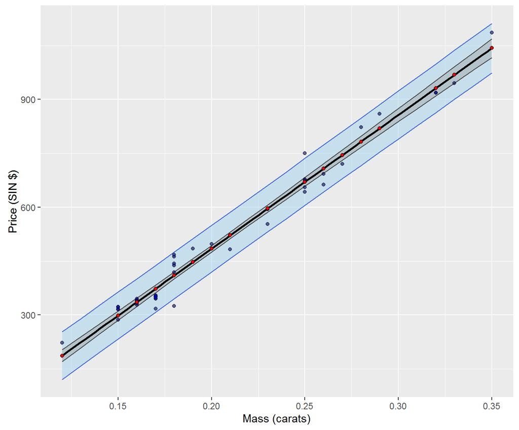

## Residuals

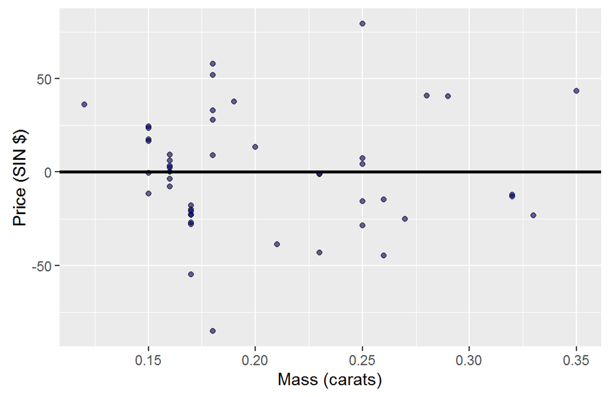

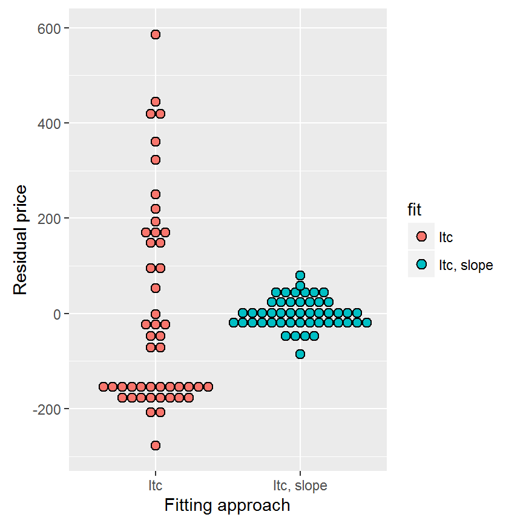